# cardinal fitness — results summaries

## TransHet survival

To assess whether the post-blood-feeding survival phenotype is caused by disruption of cardinal function, survival data were modelled for the 2360B5 and D251 lines specifically, using a Weibull parametric model (n = 186). Predictors were line (2360B5 vs D251) and genotype (Het, Hom, WT), with the reference group being 2360B5 Het.

D251 Het mosquitoes did not differ significantly from 2360B5 Het (estimate = 0.97, 95% CI: 0.40–2.34, p = 0.944). D251 WT mosquitoes showed dramatically extended survival relative to 2360B5 Het (estimate = 12218566.26, 95% CI: 0.00–Inf, p = 0.997), though the estimate is highly unstable, suggesting complete or near-complete separation in the data. Within the 2360B5 line, WT mosquitoes survived substantially longer than Het mosquitoes (estimate = 26.66, 95% CI: 11.04–64.38, p < 0.001). These results indicate that WT mosquitoes in both lines survive much longer than their KI heterozygote counterparts, but do not provide clear evidence that the D251 KO allele rescues the KI survival phenotype.

```
`r2()` does not support models of class `flexsurvreg`.
```

|  | Surv(Hours,event) |  |  |
| --- | --- | --- | --- |
| Predictors | Estimates | CI | p |
| shape | 1.335 | 0.411 – 4.334 | 0.630 |
| scale | 70.891 | 0.000 – 98038538547623231456082028620.000 | 0.894 |
| 2360B5 WT | 26.664 | 11.043 – 64.385 | **<0.001** |
| Trans-het (D251:2360 Het) | 0.969 | 0.401 – 2.340 | 0.944 |
| Het<sup>KO</sup> (D251:2360 WT) | 12218566.257 | 0.000 – Inf | 0.997 |
| Observations | 186 |  |  |

```
line_treatment=2360Het
  time      est          lcl      ucl
1  100 0.205326 2.636022e-06 0.646139

line_treatment=2360WT
  time       est       lcl       ucl
1  100 0.9804553 0.7835443 0.9999625

line_treatment=D251:2360Het
  time      est          lcl       ucl
1  100 0.191849 1.964034e-09 0.7704467

line_treatment=D251:2360WT
  time est lcl ucl
1  100   1   0   1
```

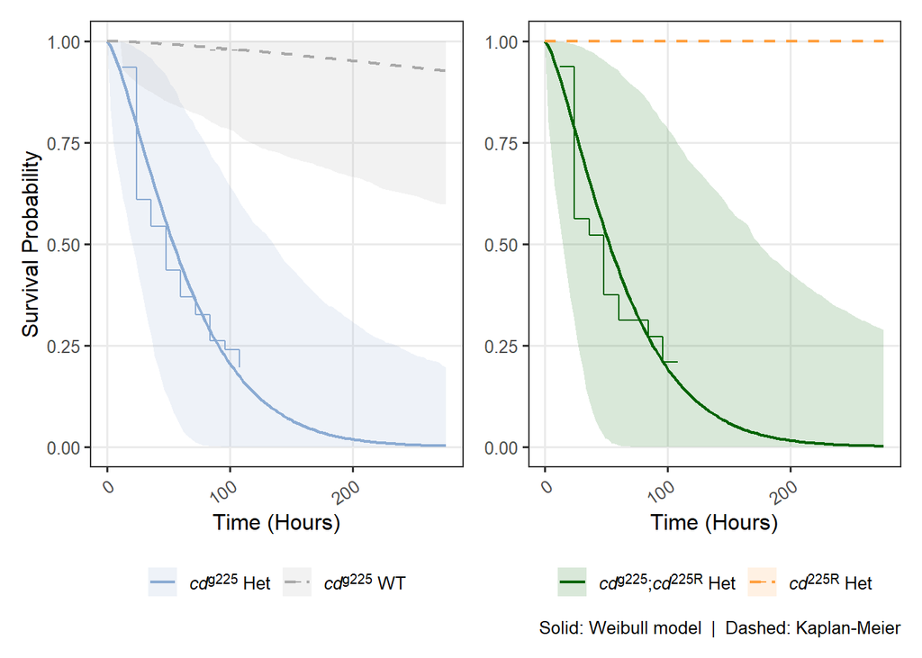

## Smurf assay

Midgut integrity was assessed using the smurf assay. The proportion of smurf-positive mosquitoes (indicating gut barrier disruption) was modelled using a binomial GLM with genotype (WT, KI, KO) as the sole predictor, restricted to sucrose-delivered mosquitoes (n = 9 cage-level observations). The reference group was WT.

KI mosquitoes had a dramatically elevated smurf rate compared to WT controls (OR = 65.6, 95% CI: 25.7–205.2, p < 0.001), confirming that the cardinal KI allele causes significant gut barrier disruption after blood feeding. The KO genotype showed a smurf rate consistent with zero events (OR ≈ 0, p = 0.996), reflecting complete separation with no observed smurf-positive cases in this genotype. Taken together, the data confirm that the KI phenotype is associated with midgut barrier disruption, while the KO allele does not share this defect.

|  | cbind(positive,negative) |  |  |
| --- | --- | --- | --- |
| Predictors | Odds Ratios | CI | p |
| Intercept (WT) | 0.06 | 0.02 – 0.13 | **<0.001** |
| KI | 65.61 | 25.70 – 205.20 | **<0.001** |
| KO | 0.00 | NA – 31797669264456545952024462424600842242442848224802464644602264206042688426284084404262622040668066022200860442044880620242602862666462408084262264446604644262206628248400628400.00 | 0.996 |
| Observations | 9 |  |  |

```
 genotype   prob       SE  df asymp.LCL asymp.UCL
 WT       0.0568 2.47e-02 Inf    0.0238     0.129
 KI       0.7981 3.94e-02 Inf    0.7100     0.864
 KO       0.0000 1.13e-06 Inf    0.0000     1.000

Confidence level used: 0.95
Intervals are back-transformed from the logit scale
```

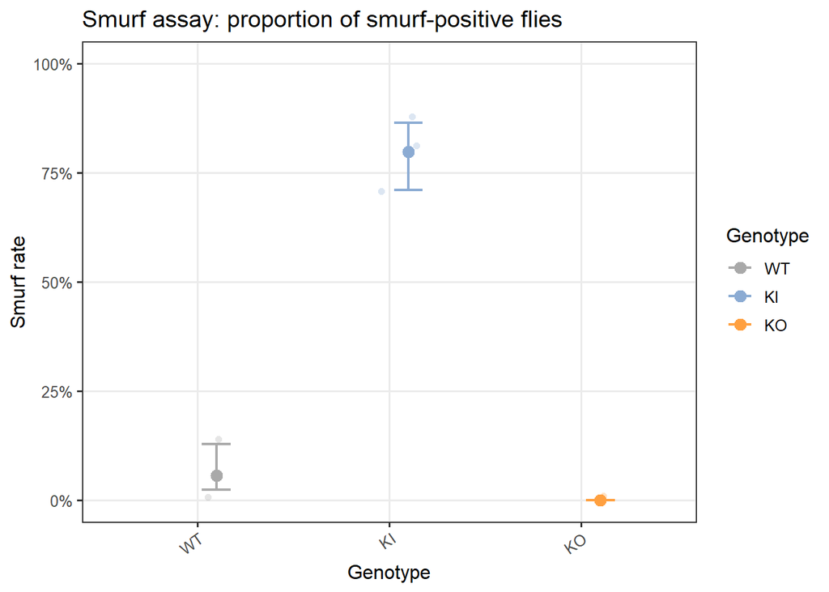

### Alternative figure as bar chart

```
`r2()` does not support models of class `flexsurvreg`.
```

[output not shown]

[output not shown]

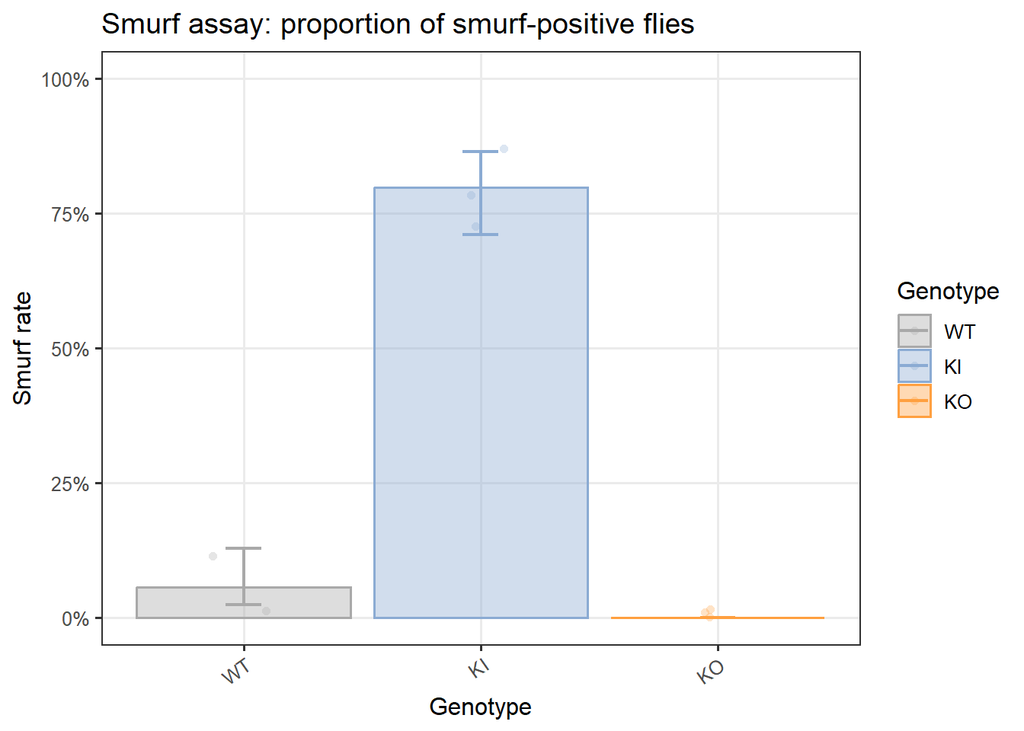

### Survival after Smurf

```
`r2()` does not support models of class `flexsurvreg`.
```

|  | Surv(hours,survival) |  |  |
| --- | --- | --- | --- |
| Predictors | Estimates | CI | p |
| shape | 2.75 | 0.40 – 18.98 | 0.305 |
| scale | 58.43 | 0.00 – 40818058648747196416.00 | 0.846 |
| line [KO] | 4900.99 | 0.00 – Inf | 0.998 |
| line [WT] | 4900.99 | 0.00 – Inf | 0.998 |
| Observations | 271 |  |  |

```
line=KO
  time est lcl ucl
1   72   1   0   1

line=KI
  time       est          lcl       ucl
1   72 0.1694089 2.220446e-16 0.8023854

line=WT
  time est lcl ucl
1   72   1   0   1
```

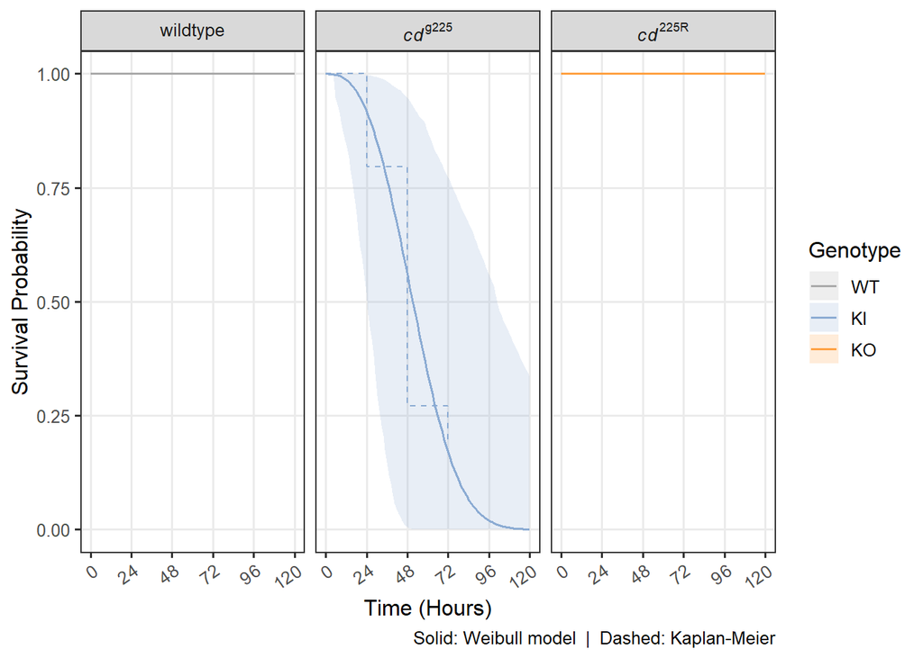

### Survival separated by smurf

```
`r2()` does not support models of class `flexsurvreg`.
```

|  | Surv(hours,survival) |  |  |
| --- | --- | --- | --- |
| Predictors | Estimates | CI | p |
| shape | 3.07 | 1.80 – 5.25 | **<0.001** |
| scale | 90.25 | 0.00 – 99042689238.77 | 0.672 |
| smurf [Smurf-positive] | 0.58 | 0.45 – 0.74 | **<0.001** |
| Observations | 104 |  |  |

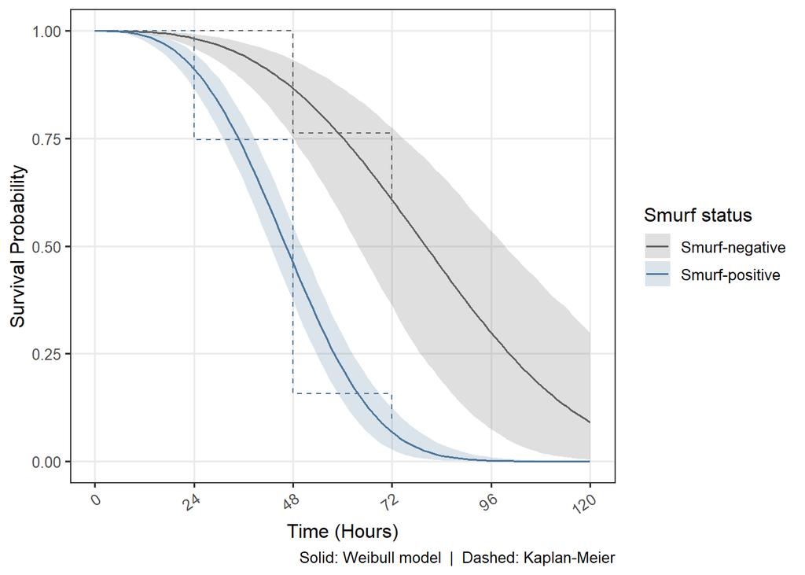

## XA Supplementation

```
`r2()` does not support models of class `flexsurvreg`.
```

|  | Surv(Hours,event) |  |  |
| --- | --- | --- | --- |
| Predictors | Estimates | CI | p |
| shape | 2.17 | 1.27 – 3.71 | **0.004** |
| scale | 94.74 | 0.00 – 258334014336.69 | 0.681 |
| Sugar supplementation | 1.65 | 1.27 – 2.15 | **<0.001** |
| 6 mM NaOH control | 0.92 | 0.69 – 1.21 | 0.534 |
| 6 mM XA | 1.64 | 1.15 – 2.35 | **0.006** |
| WT | 6.63 | 2.41 – 18.28 | **<0.001** |
| Observations | 244 |  |  |

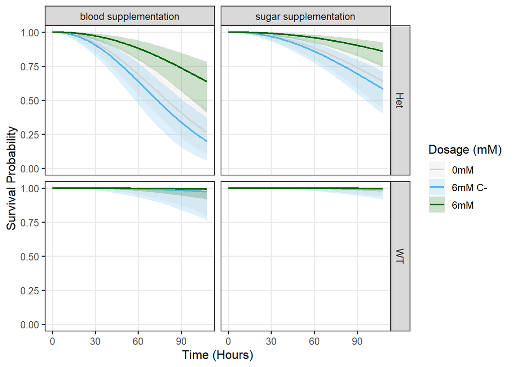

```
experiment=blood supplementation,dosage_mM=0mM,genotype=WT
  time       est       lcl       ucl
1   72 0.9910227 0.9186672 0.9989538

experiment=blood supplementation,dosage_mM=6mM C-,genotype=WT
  time       est       lcl       ucl
1   72 0.9891423 0.8950334 0.9987453

experiment=blood supplementation,dosage_mM=6mM,genotype=WT
  time       est       lcl       ucl
1   72 0.9969414 0.9734616 0.9996445

experiment=blood supplementation,dosage_mM=0mM,genotype=Het
  time       est       lcl       ucl
1   72 0.5765642 0.4105707 0.7263485

experiment=blood supplementation,dosage_mM=6mM C-,genotype=Het
  time       est       lcl       ucl
1   72 0.5134301 0.3333158 0.6687579

experiment=blood supplementation,dosage_mM=6mM,genotype=Het
  time       est       lcl       ucl
1   72 0.8293943 0.7090819 0.9080196

experiment=sugar supplementation,dosage_mM=0mM,genotype=WT
  time       est       lcl      ucl
1   72 0.9969773 0.9743585 0.999649

experiment=sugar supplementation,dosage_mM=6mM C-,genotype=WT
  time       est       lcl       ucl
1   72 0.9963419 0.9685495 0.9996083

experiment=sugar supplementation,dosage_mM=6mM,genotype=WT
  time       est       lcl      ucl
1   72 0.9989722 0.9913818 0.999885

experiment=sugar supplementation,dosage_mM=0mM,genotype=Het
  time       est       lcl       ucl
1   72 0.8312238 0.7326829 0.9034301

experiment=sugar supplementation,dosage_mM=6mM C-,genotype=Het
  time       est       lcl      ucl
1   72 0.7994849 0.6937359 0.879632

experiment=sugar supplementation,dosage_mM=6mM,genotype=Het
  time       est       lcl       ucl
1   72 0.9391362 0.8786214 0.9721295
```

## Homozygous Survival

|  | cbind(Adults,200-Adults) |  |  |
| --- | --- | --- | --- |
| Predictors | Odds Ratios | CI | p |
| Intercept (*cd*<sup>384R</sup> HET female) | 0.83 | 0.68 – 1.01 | 0.058 |
| Line (*cd*<sup>g384</sup> vs *cd*<sup>384R</sup>) | 1.22 | 0.93 – 1.61 | 0.157 |
| WT | 0.95 | 0.72 – 1.26 | 0.722 |
| HOM | 1.22 | 0.93 – 1.61 | 0.157 |
| Male | 1.15 | 0.87 – 1.52 | 0.321 |
| *cd*<sup>g384</sup> × WT | 0.79 | 0.53 – 1.17 | 0.230 |
| *cd*<sup>g384</sup> × HOM | 0.01 | 0.00 – 0.02 | **<0.001** |
| *cd*<sup>g384</sup> × Male | 0.76 | 0.51 – 1.12 | 0.161 |
| WT × Male | 1.20 | 0.81 – 1.78 | 0.368 |
| HOM × Male | 0.71 | 0.48 – 1.05 | 0.089 |
| *cd*<sup>g384</sup> × WT × Male | 1.42 | 0.81 – 2.48 | 0.215 |
| *cd*<sup>g384</sup> × HOM × Male | 33.42 | 10.79 – 147.54 | **<0.001** |
| Observations | 24 |  |  |

## qPCR

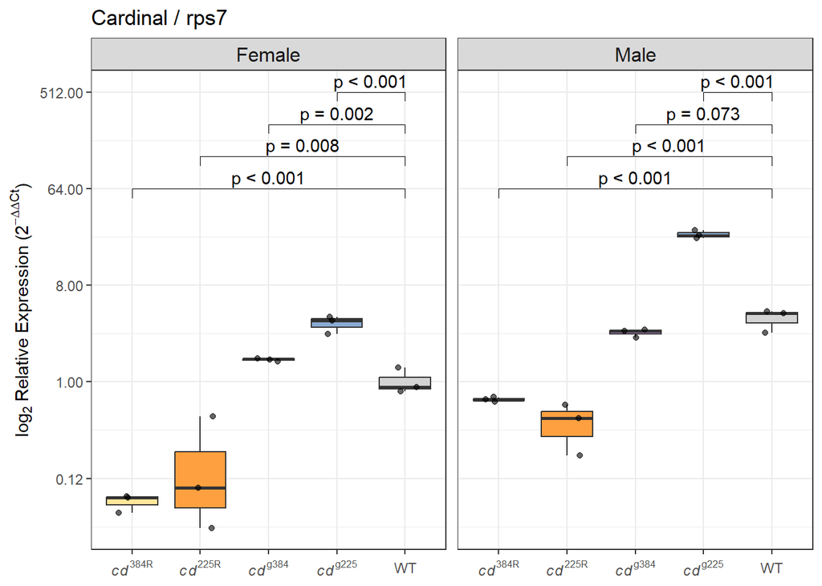

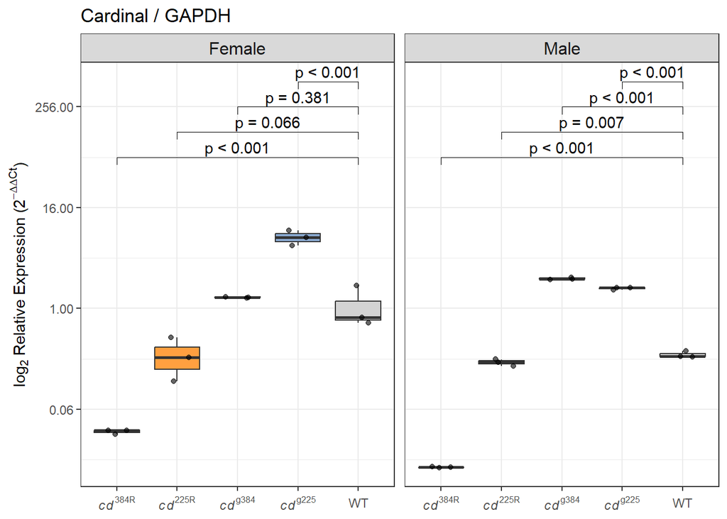